# Getting Started with ‘gggrid’

The ‘gggrid’ package provides two functions: `grid_panel()` and `grid_group()`. Both functions add ‘grid’ output to a ‘ggplot2’ plot.

The `grid_panel()` function is called once for each panel in a (facetted) ‘ggplot2’ plot and the `grid_group()` function is called once for each group in a ‘ggplot2’ plot.

The first argument to both functions can be a ‘grid’ grob. For example, the following code defines a text grob that will be drawn 5mm in from the top-right corner of wherever it is drawn.

```r
library(grid)
label <- textGrob("Label",
                  x=unit(1, "npc") - unit(5, "mm"),
                  y=unit(1, "npc") - unit(5, "mm"),
                  just=c("right", "top"))
```

The following code calls `grid_panel()` to add that text label to a ‘ggplot2’ plot.

```r
library(gggrid)
```

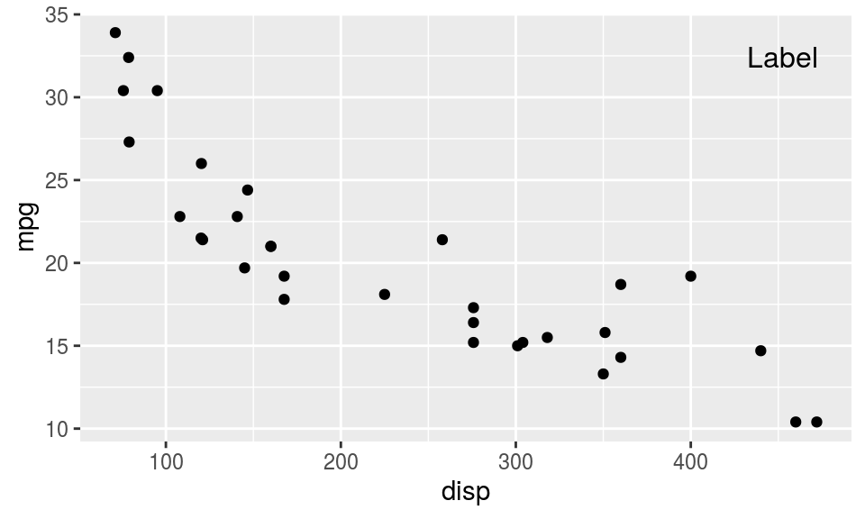

```r
ggplot(mtcars) +
    geom_point(aes(disp, mpg)) +
    grid_panel(label)
```

The first argument to both functions can also be a function that generates a grob. The function must accept two arguments, `data` and `coords`, which contain the data values (and transformed data values) for the ‘ggplot2’ panel that is being drawn. For example, the following code adds a “rug” of short lines showing the distribution of the y-values in the plot.

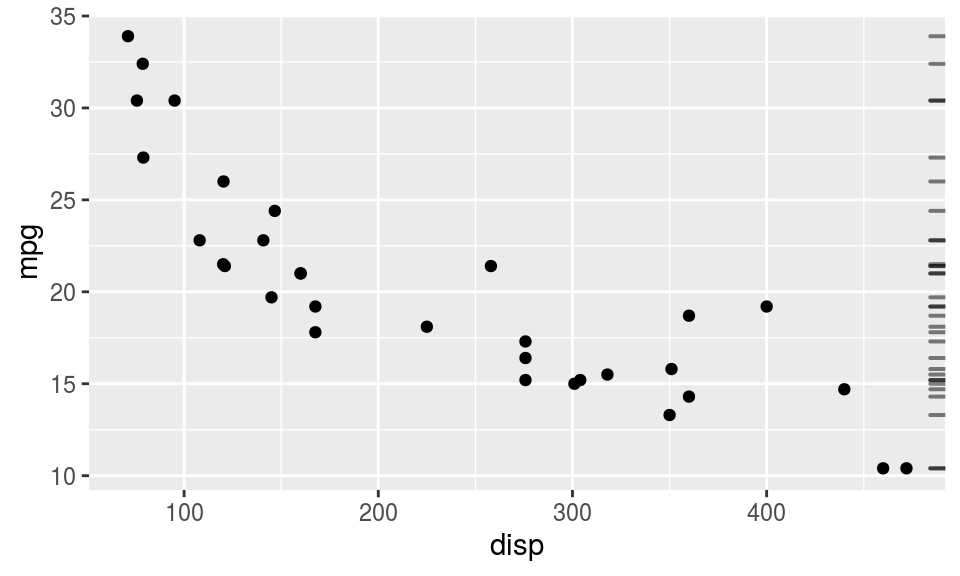

```r
rug <- function(data, coords) {
    segmentsGrob(unit(1, "npc"),
                 coords$y,
                 unit(1, "npc") - unit(2, "mm"),
                 coords$y,
                 gp=gpar(lwd=2, col=rgb(0,0,0,.5)))
}
ggplot(mtcars, aes(x=disp, y=mpg)) +
    geom_point() +
    grid_panel(rug)
```

The following code adds facetting to demonstrate that `grid_panel()` is called once for panel.

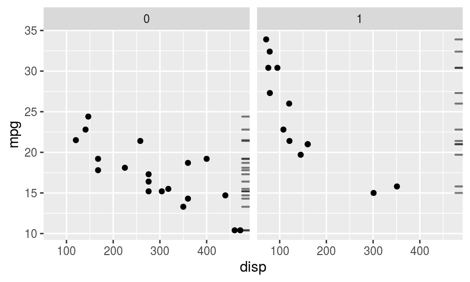

```r
ggplot(mtcars, aes(x=disp, y=mpg)) +
    geom_point() +
    grid_panel(rug) +
    facet_wrap("am")
```

The following code adds grouping to demonstrate that `grid_group()` is called once for each group.

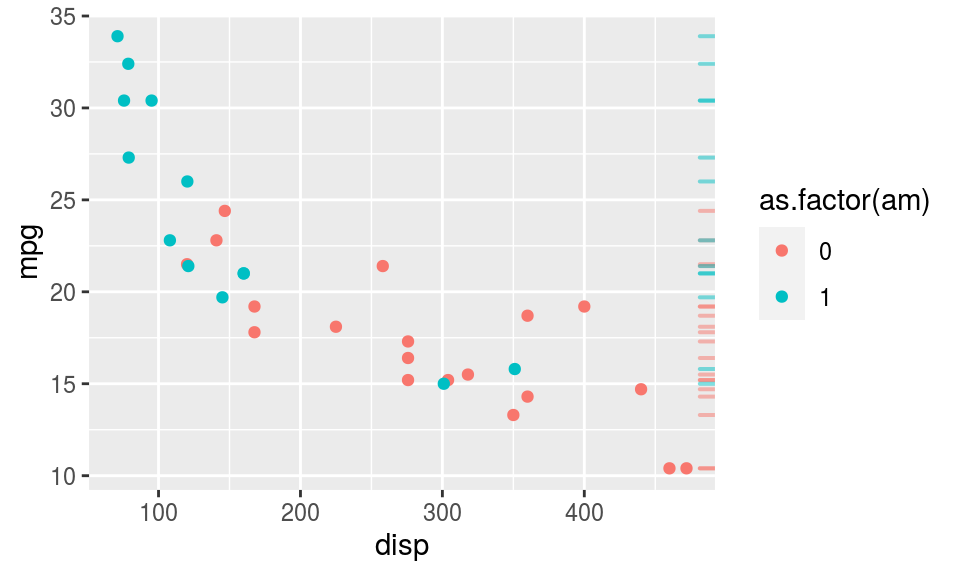

```r
rugGroup <- function(data, coords) {
    segmentsGrob(unit(1, "npc"),
                 coords$y,
                 unit(1, "npc") - unit(2, "mm"),
                 coords$y,
                 gp=gpar(lwd=2, col=adjustcolor(data$colour, alpha=.5)))
}
ggplot(mtcars, aes(x=disp, y=mpg, colour=as.factor(am))) +
    geom_point() +
    grid_group(rugGroup)
```

The following code demonstrates that ‘gggrid’ is one way to access ‘grid’-based drawing that is not (yet) available via ‘ggplot2’-based `geom_*()` functions. In this case, we make use of variable-width lines from the ‘vwline’ package.

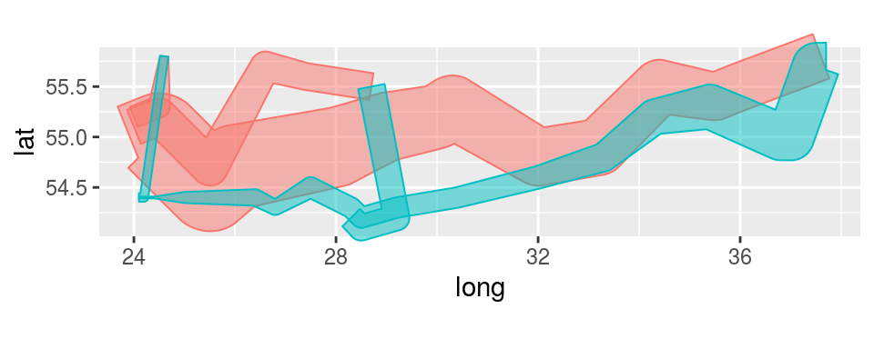

```r
minard <- read.table("minard-troops.txt", header=TRUE)
library(vwline)
path <- function(data, coords) {
    vwlineGrob(coords$x, coords$y, w=unit(coords$size, "in"),
               gp=gpar(col=coords$colour[1],
                       fill=adjustcolor(coords$colour[1], alpha=.5)))
}
ggplot(minard,
       aes(x=long, y=lat, size=survivors, colour=direction,
           group=interaction(group, direction))) +
    scale_size(range=c(.01, .5)) +
    coord_fixed(2, clip="off") +
    grid_group(path)
```

The above plot has no legend, but it is possible to add one with a little more work. There are three important steps:

1. Set `show.legend=TRUE`
2. Set `key_glyph` to be a function that produces a grob (to draw an item in the legend)
3. Set an explicit mapping in the `grid_group()` call (rather than just having `grid_group()` inherit a mapping).

The following code demonstrates these steps, including defining a `path_key()` function that draws a variable-width line in the legend, to show the relationship between `colour` and `direction`.

We have excluded the `size` legend in this case (with `guide="none"`) to keep the `path_key()` function relatively simple.

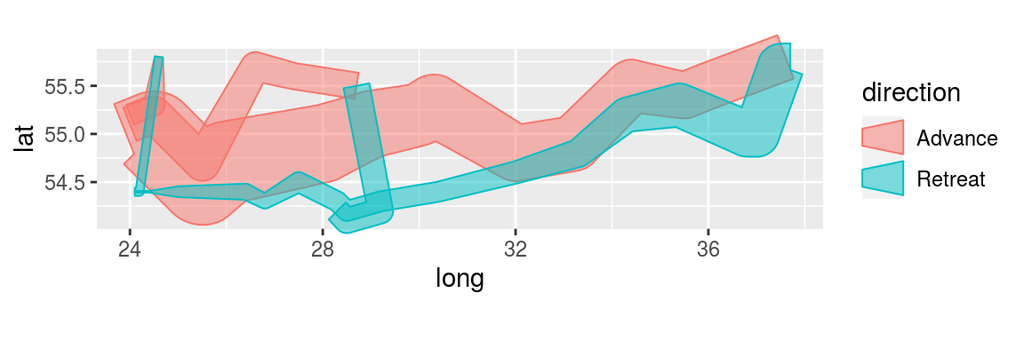

```r
path_key <- function(data, ...) {
    vwlineGrob(0:1, c(.5, .5), w=unit(c(.1, .2), "in"),
               gp=gpar(col=data$colour,
                       fill=adjustcolor(data$colour, alpha=.5)))
}
ggplot(minard) +
    scale_size(range=c(.01, .5), guide="none") +
    coord_fixed(2, clip="off") +
    grid_group(path,
               aes(x=long, y=lat, size=survivors, colour=direction,
                   group=interaction(group, direction)),
               show.legend=TRUE,
               key_glyph=path_key)
```

The Minard data used in the example above comes from the supplementary materials that were published with Wickham (2010).

## References

Wickham, Hadley. 2010. “A Layered Grammar of Graphics.” *Journal of Computational and Graphical Statistics* 19 (1): 3–28. https://doi.org/10.1198/jcgs.2009.07098.